# Colorado temperature analysis

Sudipto Banerjee

## Colorado spring temperature data

These data were originally part of the `fields` package’s `COmonthlyMet` dataset. Begin by removing all objects from memory for a fresh start. Then load the Rdata

```r
rm(list = ls())
load("../data/CO-temp-data.RData")
ls()
```

```
[1] "coords"      "elev"        "pred.coords" "pred.elev"   "temp"
```

Our goal is to create a complete prediction surface of minimum spring temperature with associated estimates of uncertainty.

```r
library(fields)
library(MBA)
library(geoR)
library(sf)
library(leaflet)
```

We set up a `leaflet` “base map” to help visualize the data.

```r
blue.red <- c("#2c7bb6", "#abd9e9", "#ffffbf", "#fdae61", "#d7191c")

base.map <- leaflet(width = "100%") %>%
    addProviderTiles("Esri.WorldImagery", group = "Satellite") %>%
    addLayersControl(baseGroup = c("Satellite"), options = layersControlOptions(collapsed = FALSE))
```

Take a look at station locations and mean minimum spring temperatures across Colorado. You can zoom in and out as well.

```r
pal <- colorNumeric(blue.red, domain = temp)

base.map %>%
    addCircleMarkers(lng = coords[, 1], lat = coords[, 2], col = pal(temp), stroke = FALSE,
        radius = 5, fillOpacity = 0.9, popup = paste("Mean min temp:", round(temp,
            1))) %>%
    addLegend("bottomright", pal = pal, values = temp, opacity = 0.9, title = "Temperature C")
```

[interactive chart not shown]

We’ll reproject the geographic coordinates (i.e., longitude and latitude) to a coordinate system that provides a bit more intuition about distance and reduces spatial distortion. We will use a widely used projection system called the Universal Transverse Mercator (UTM) coordinate system. This system first uses a transverse Mercator projection to transform the geographic coordinates to planar coordinates. The Mercator projection preserves directions or angles (is a conformal projection), but distorts distances. In order to minimize the distortion of distances, the UTM coordinate system divides the earth into 60 zones, each of width 6 degrees, and uses the transverse Mercator projection in each zone. The UTM projection is widely used in scientific applications of spatial data when most of the locations fall within a single UTM zone. A useful excercise here is to use write 2 functions: one to locate a point’s UTM zone; and a second to find the zone where most of the points lie in.

```r
lon2UTM <- function(longitude) {
    (floor((longitude + 180)/6)%%60) + 1
}  ##Function to find the UTM zone of a geographic coordinate in the western hemisphere (only longitude is needed).

Mode <- function(x, na.rm = FALSE) {
    if (na.rm) {
        x = x[!is.na(x)]
    }

    ux <- unique(x)
    return(ux[which.max(tabulate(match(x, ux)))])
}  ##Function to calculate the mode of the above data to find which zone contains most of the points
utmZone <- Mode(lon2UTM(coords$lon))
utmZone
```

```
[1] 13
```

The UTM projection uses only one zone to project all the points and, hence, works best if all the points fit into one zone. However, in practice, we could use the two functions defined above to choose the zone where most of the points lie and use that zone as an approximation. We also convert the UTM distance units from meters to kilometers.

```r
coordsGeog <- st_as_sf(coords, coords = c("lon", "lat"), crs = "+proj=longlat +datum=WGS84 +no_defs")
coordsUTM <- st_transform(coordsGeog, crs = "+proj=utm +zone=13 +ellps=WGS84 +datum=WGS84 +units=m +no_defs")
coordsUTM <- st_coordinates(coordsUTM)/1000
class(coordsUTM)
```

```
[1] "matrix" "array"
```

Let us create a new data frame with with the variables temperature, elevation (after converting it to kms) and the projected coordinates.

```r
elev <- elev/1000
df <- data.frame(temp, elev, coordsUTM)
names(df) <- c("temp", "elev", "xUTM", "yUTM")
```

We will now turn to Bayesian hierarchical modeling using `nimble`. Load the package.

```r
library("nimble")
```

We will build a simple linear regression model in `nimble`.

```r
lmCode <- nimbleCode({
    for (i in 1:N) {
        Y[i] ~ dnorm(mu[i], tausq)
        mu[i] <- inprod(X[i, 1:p], beta[1:p])
        yFit[i] ~ dnorm(mu[i], tausq)
        yResid[i] <- Y[i] - mu[i]
    }

    for (i in 1:p) {
        beta[i] ~ dflat()
    }
    tausq ~ dgamma(1e-05, 1e-05)
    sigma <- 1/sqrt(tausq)
})
```

Define the model parameters to be recognized by the nimble model.

```r
modelParameters <- c("beta", "tausq", "sigma", "yFit", "yResid")
```

We will first fit a simple linear regression with temperature as the dependent variable and the two spatial coordinates as the predictors. Create the data, constants and also a list of initial values.

```r
nimbleData <- list(Y = df$temp)
N <- nrow(df)
X <- cbind(rep(1, times = N), df$xUTM, df$yUTM)
p <- ncol(X)
nimbleConstants <- list(N = N, X = X, p = p)
nimbleInits <- list(beta = rep(0, times = p), tausq = 1, yFit = rep(0, times = N))
```

Create the “nimbleModel” object.

```r
rModel <- nimbleModel(code = lmCode, constants = nimbleConstants, data = nimbleData,
    inits = nimbleInits)
```

```
Defining model
```

```
Building model
```

```
Setting data and initial values
```

```
Running calculate on model
  [Note] Any error reports that follow may simply reflect missing values in model variables.
```

```
Checking model sizes and dimensions
```

Specify the inputs to `nimbleMCMC`: (i) number of chains to run; (ii) number of iteratiors per chain; and (iii) number of initial iterations to let the chains “burn” (these samples will be discarded and not used for posterior inference).

```r
n_iter = 11000  ## Number of iterations
n_chains = 1  ## Number of different chains
n_burn = 1000  ## Number of initial iterations ('burn' period) for MCMC to converge. These samples will be discarded and not used in posterior inference.
```

Create the `nimbleMCMC` object to compile the code and run the MCMC algorithm. Set `WAIC=TRUE` to compute and store the “Watanabe-Akaike Information Criterion” model assessment score.

```r
mcmc.out <- nimbleMCMC(model = rModel, nchains = n_chains, niter = n_iter, nburnin = n_burn,
    monitor = modelParameters, WAIC = TRUE)
```

```
Compiling
  [Note] This may take a minute.
  [Note] Use 'showCompilerOutput = TRUE' to see C++ compilation details.
```

```
running chain 1...
```

```
|-------------|-------------|-------------|-------------|
|-------------------------------------------------------|
```

Find WAIC score.

```r
mcmc.out$WAIC
```

```
nimbleList object of type waicNimbleList
Field "WAIC":
[1] 1103.532
Field "lppd":
[1] -548.3321
Field "pWAIC":
[1] 3.433973
```

Extract posterior samples:

```r
samps <- rbind(mcmc.out$samples)
dim(samps)
```

```
[1] 10000   431
```

Obtain medians and 95% credible intervals for the model parameters from these samples

```r
credibleIntervals <- t(apply(samps, 2, function(x) {
    quantile(x, c(0.5, 0.025, 0.975))
}))
```

Extract credible intervals for specific variable(s):

```r
CI_beta <- credibleIntervals[grep("beta", rownames(credibleIntervals)), ]
CI_beta
```

```
                 50%         2.5%         97.5%
beta[1]  9.838887068 -0.878453477 14.6221197308
beta[2]  0.007259144  0.005187986  0.0093916405
beta[3] -0.003382611 -0.004470174 -0.0008767634
```

```r
CI_sigma <- credibleIntervals[grep("sigma", rownames(credibleIntervals)), ]
CI_sigma
```

```
     50%     2.5%    97.5%
3.198185 2.911366 3.527434
```

Get the posterior median of the residuals:

```r
CI_yResid <- credibleIntervals[grep("yResid", rownames(credibleIntervals)), ]
yResidPosteriorMedians <- CI_yResid[, grep("50%", colnames(CI_yResid))]
```

Next let’s take a look at the regression model residuals, assess their spatial independence, and start thinking about variogram and covariance parameters.

```r
dMax <- max(rdist(coordsUTM))
dMax
```

```
[1] 841.6322
```

```r
vTemp <- variog(coords = coordsUTM, data = df$temp, uvec = (seq(0, 0.75 * dMax, length = 20)))
```

```
variog: computing omnidirectional variogram
```

```r
vResid <- variog(coords = coordsUTM, data = yResidPosteriorMedians, uvec = (seq(0,
    0.75 * dMax, length = 20)))
```

```
variog: computing omnidirectional variogram
```

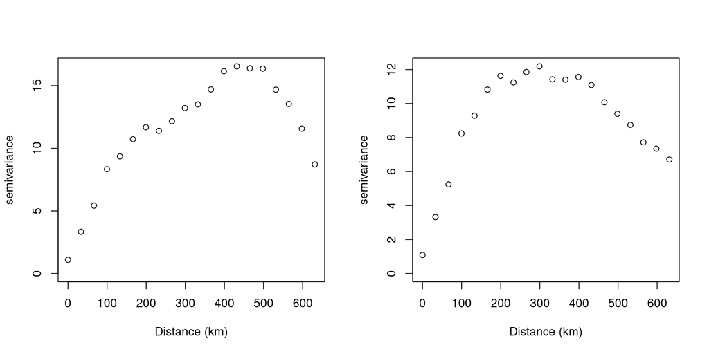

```r
par(mfrow = c(1, 2))
plot(vTemp, xlab = "Distance (km)")
plot(vResid, xlab = "Distance (km)")
```

It is also helpful to create an interpolated surface of the model residuals to further assess spatial structure and potentially identify missing covariates.

```r
resid.surf <- mba.surf(cbind(coords, yResidPosteriorMedians), no.X = 200, no.Y = 200,
    extend = TRUE, sp = TRUE)$xyz.est

library(sp)
library(raster)

proj4string(resid.surf) <- "+proj=longlat +datum=WGS84"

resid.surf <- raster(resid.surf)

pal <- colorNumeric(blue.red, values(resid.surf), na.color = "transparent")

base.map %>%
    addRasterImage(resid.surf, colors = pal, opacity = 0.75, group = "Regression residuals") %>%
    addLegend("bottomright", pal = pal, values = values(resid.surf), opacity = 0.75,
        title = "<center>Regression<br> residuals</center>") %>%
    addLayersControl(baseGroup = c("Satellite"), overlayGroups = c("Regression residuals"),
        options = layersControlOptions(collapsed = FALSE))
```

[interactive chart not shown]